# Feminicídio e fatores socioeconômicos

## 1. Introdução

Este notebook documenta, de forma reprodutível, a exploração da API pública do Atlas da Violência (IPEA) e uma análise exploratória inicial das séries selecionadas. Fonte: https://www.ipea.gov.br/atlasviolencia/api

```python
import time
import json
from typing import Dict, Any, Optional, List, Tuple

import requests
import pandas as pd
import numpy as np
import matplotlib.pyplot as plt

pd.set_option("display.max_columns", 200)
pd.set_option("display.width", 140)
```

## 2. Teste de conexão da API

```python
API = [
    "https://www.ipea.gov.br/atlasviolencia/api",
]

def _try_get(url: str, timeout: int = 30) -> requests.Response:
    r = requests.get(url, timeout=timeout)
    r.raise_for_status()
    return r

def detect_base_url() -> str:
    for base in API:
        for prefix in ["", "/api"]:
            test = f"{base}{prefix}/v1/temas"
            try:
                _try_get(test)
                return f"{base}{prefix}"
            except Exception:
                pass
    raise RuntimeError("Falhou")

BASE_URL = detect_base_url()
BASE_URL
```

```
'https://www.ipea.gov.br/atlasviolencia/api'
```

### 2.1 Client de consumo de dados

A seguir um client simples para:

- montar URLs
- aplicar parâmetros de query (`inicial`, `final`, etc.)
- tratar erros HTTP
- permitir repetição com backoff em falhas transitórias

```python
SESSION = requests.Session()
SESSION.headers.update({"User-Agent": "Mozilla/5.0"})

def api_get(path: str, params: Optional[Dict[str, Any]] = None, timeout: int = 60, retries: int = 3, backoff: float = 1.5):
    url = f"{BASE_URL}{path}"
    last_err = None
    for i in range(retries):
        try:
            r = SESSION.get(url, params=params, timeout=timeout)
            r.raise_for_status()
            return r.json()
        except Exception as e:
            last_err = e
            time.sleep(backoff ** i)
    raise last_err

def head(obj, n=10):
    if isinstance(obj, list):
        return obj[:n]
    return obj
```

### 2.2. Catalogação: temas, unidades, fontes, periodicidades etc

Coleta de metadados para entender:

- quais temas existem
- quais séries existem por tema
- quais unidades de medida e periodicidades estão disponíveis
- quais fontes e indicadores são referenciados

A saída é o "dicionário" para navegar na API.

```python
temas = api_get("/v1/temas")
unidades = api_get("/v1/unidades")
fontes = api_get("/v1/fontes")
periodicidades = api_get("/v1/periodicidades")
df_temas = pd.DataFrame(temas)
df_unidades = pd.DataFrame(unidades)
df_fontes = pd.DataFrame(fontes)
df_period = pd.DataFrame(periodicidades)
df_indic = pd.DataFrame(indicadores)

df_temas.head(100)
```

|  | id | titulo | tema_id | imagem | tipo | subTemas |
| --- | --- | --- | --- | --- | --- | --- |
| 0 | 1 | Homicídios | 0 | 4943-homicidios.png | 0 | [] |
| 1 | 2 | Juventude Perdida | 0 | 1260-juventude.png | 0 | [] |
| 2 | 4 | Mortes Violentas por Causa Indeterminada | 0 | 6467-causaindeterminada.png | 0 | [] |
| 3 | 5 | Óbitos por Armas de Fogo | 0 | 9895-armafogo.png | 0 | [] |
| 4 | 15 | Óbitos por Causas Externas | 0 | 1068-causasexternas.png | 0 | [] |
| 5 | 16 | Suicídio | 0 | 9675-suicidio.png | 0 | [] |
| 6 | 58 | Violência Física | 0 | 8759-fisica.png | 0 | [] |
| 7 | 12 | Violência no Trânsito | 0 | 3962-transito.png | 0 | [] |
| 8 | 61 | Violência por Gênero | 0 | 1172-genero.png | 0 | [] |
| 9 | 3 | Violência por Raça | 0 | 4028-raca.png | 0 | [] |
| 10 | 60 | Violência Psicológica | 0 | 4434-psicologica.png | 0 | [] |
| 11 | 59 | Violência Sexual | 0 | 6608-sexual.png | 0 | [] |

O eixo escolhido foi o 1 (homicídios)

```python
df_temas[["id", "titulo"]].sort_values("id").head(30)
```

|  | id | titulo |
| --- | --- | --- |
| 0 | 1 | Homicídios |
| 1 | 2 | Juventude Perdida |
| 9 | 3 | Violência por Raça |
| 2 | 4 | Mortes Violentas por Causa Indeterminada |
| 3 | 5 | Óbitos por Armas de Fogo |
| 7 | 12 | Violência no Trânsito |
| 4 | 15 | Óbitos por Causas Externas |
| 5 | 16 | Suicídio |
| 6 | 58 | Violência Física |
| 11 | 59 | Violência Sexual |
| 10 | 60 | Violência Psicológica |
| 8 | 61 | Violência por Gênero |

### 2.3. Séries por tema e escolha de séries-alvo

A API organiza séries por `tema_id`. A etapa abaixo permite:

1. buscar temas por palavra-chave
2. listar séries do(s) tema(s) escolhido(s)
3. selecionar `serie_id`(s) para análise

Observação: a escolha das séries deve ser justificada pela pergunta de pesquisa.

```python
def find_temas(keyword: str) -> pd.DataFrame:
    k = keyword.lower().strip()
    return df_temas[df_temas["titulo"].astype(str).str.lower().str.contains(k, na=False)][["id","titulo"]].sort_values("id")

find_temas("gênero")
```

|  | id | titulo |
| --- | --- | --- |
| 8 | 61 | Violência por Gênero |

Em resumo: selecionamos o eixo 1 > homicídios e o tema 61 > Violência por gênero  
O propósito é analisar dados de femicídio, com essa combinação conseguimos elencar os dados necessários para as análises

```python
TEMA_ID = 61
series = api_get(f"/v1/series/{TEMA_ID}")
df_series = pd.DataFrame(series)
df_series
```

|  | id | titulo |
| --- | --- | --- |
| 0 | 160 | Homicídios de Homens por Armas de Fogo |
| 1 | 71 | Homicídios de Jovens - Homens |
| 2 | 74 | Homicídios de Jovens - Mulheres |
| 3 | 162 | Homicídios de Mulheres por Armas de Fogo |
| 4 | 39 | Homicídios Homens |
| ... | ... | ... |
| 80 | 220 | Violência Sexual - Mulheres Jovens (Percentual) |
| 81 | 294 | Violência Sexual - Mulheres Não-Negras |
| 82 | 219 | Violência Sexual - Mulheres Não-Negras (Percen... |
| 83 | 293 | Violência Sexual - Mulheres Negras |
| 84 | 218 | Violência Sexual - Mulheres Negras (Percentual) |

85 rows × 2 columns

```python
df_series.columns = [c.strip().lower() for c in df_series.columns]

filtro = "homic"
df_series_like = df_series[df_series["titulo"].astype(str).str.contains(filtro, case=False, na=False)].copy()

df_series_like[["id", "titulo"]].sort_values("titulo").reset_index(drop=True)
```

|  | id | titulo |
| --- | --- | --- |
| 0 | 39 | Homicídios Homens |
| 1 | 144 | Homicídios Homens Negros |
| 2 | 145 | Homicídios Homens Não Negros |
| 3 | 40 | Homicídios Mulheres |
| 4 | 142 | Homicídios Mulheres Negras |
| 5 | 143 | Homicídios Mulheres Não Negras |
| 6 | 160 | Homicídios de Homens por Armas de Fogo |
| 7 | 71 | Homicídios de Jovens - Homens |
| 8 | 74 | Homicídios de Jovens - Mulheres |
| 9 | 162 | Homicídios de Mulheres por Armas de Fogo |
| 10 | 164 | Taxa de Homicídio de Mulheres por Armas de Fogo |
| 11 | 51 | Taxa de Homicídios Homens |
| 12 | 146 | Taxa de Homicídios Homens Negros |
| 13 | 147 | Taxa de Homicídios Homens Não Negros |
| 14 | 52 | Taxa de Homicídios Mulheres |
| 15 | 128 | Taxa de Homicídios Mulheres Negras |
| 16 | 126 | Taxa de Homicídios Mulheres Não Negras |
| 17 | 161 | Taxa de Homicídios de Homens por Armas de Fogo |
| 18 | 148 | Taxa de Homicídios de Jovens - Homens |
| 19 | 149 | Taxa de Homicídios de Jovens - Mulheres |

Aqui selecionamos as séries relacionados a homícios por sexo de mulheres:  
40 Homicídios Mulheres  
74 Homicídios de Jovens - Mulheres  
142 Homicídios Mulheres Negras  
143 Homicídios Mulheres Não Negras  
162 Homicídios de Mulheres por Armas de Fogo

### 2.4. valores da série por abrangência e período

A API expõe duas rotas principais para valores:

- `valores-series/{serie_id}/{abrangencia}`: traz valores na abrangência solicitada
- `valores-series-por-regioes/{serie_id}/{abrangencia}/{regioes}`: filtra por uma região/UF/município específico

Convenção de `abrangencia`: 1 = País, 2 = Região, 3 = UF, 4 = Município

Usaremos a maior abrangencia de geolocalização: Município (4)

```python
SERIE_ID = int(df_series.iloc[0]["id"])

def get_valores_serie(serie_id: int, abrangencia: int, inicial: Optional[str] = None, final: Optional[str] = None):
    params = {}
    if inicial is not None:
        params["inicial"] = inicial
        params["final"] = final
    return api_get(f"/v1/valores-series/{serie_id}/{abrangencia}", params=params if params else None)

def get_valores_por_regiao(serie_id: int, abrangencia: int, regiao: str, inicial: Optional[str] = None, final: Optional[str] = None):
    params = {}
    if inicial is not None:
        params["inicial"] = inicial
        params["final"] = final
    return api_get(f"/v1/valores-series-por-regioes/{serie_id}/{abrangencia}/{regiao}", params=params if params else None)

valores_bra = get_valores_serie(SERIE_ID, 1, inicial="1989", final="2023")
df_bra = pd.DataFrame(valores_bra)
df_bra.head()
```

|  | cod | sigla | valor | periodo |
| --- | --- | --- | --- | --- |
| 0 | 1076 | BRA | 12624 | 1989-01-15 |
| 1 | 1076 | BRA | 15454 | 1990-01-15 |
| 2 | 1076 | BRA | 14599 | 1991-01-15 |
| 3 | 1076 | BRA | 13743 | 1992-01-15 |
| 4 | 1076 | BRA | 15822 | 1993-01-15 |

## 3. Preparação da base

Nesta etapa:

- padronizamos nomes e tipos
- adicionamos colunas-chave (`serie_id`, `abrangencia`)
- juntamos metadados da série (título, unidade, periodicidade, fonte)

O resultado é uma tabela analítica "longa", adequada para EDA e modelos

```python
def normalize_valores(df: pd.DataFrame, serie_id: int, abrangencia: int) -> pd.DataFrame:
    out = df.copy()
    out.columns = [c.strip().lower() for c in out.columns]
    out["serie_id"] = serie_id
    out["abrangencia"] = abrangencia
    if "periodo" in out.columns:
        out["periodo"] = out["periodo"].astype(str)
    if "valor" in out.columns:
        out["valor"] = pd.to_numeric(out["valor"], errors="coerce")
    return out

df_bra_n = normalize_valores(df_bra, SERIE_ID, 1)
df_bra_n.head()
```

|  | cod | sigla | valor | periodo | serie_id | abrangencia |
| --- | --- | --- | --- | --- | --- | --- |
| 0 | 1076 | BRA | 12624 | 1989-01-15 | 160 | 1 |
| 1 | 1076 | BRA | 15454 | 1990-01-15 | 160 | 1 |
| 2 | 1076 | BRA | 14599 | 1991-01-15 | 160 | 1 |
| 3 | 1076 | BRA | 13743 | 1992-01-15 | 160 | 1 |
| 4 | 1076 | BRA | 15822 | 1993-01-15 | 160 | 1 |

### 3.1 Anexar metadados da série

```python
series_row = df_series[df_series["id"] == SERIE_ID].iloc[0].to_dict()

def build_lookup(df: pd.DataFrame, key: str = "id", val: str = "titulo") -> Dict[Any, Any]:
    return dict(zip(df[key], df[val]))

lk_unidade = build_lookup(df_unidades, "id", "titulo")
lk_period = build_lookup(df_period, "id", "titulo")
lk_fonte = build_lookup(df_fontes, "id", "titulo")

meta = {
    "serie_titulo": series_row.get("titulo"),
    "unidade_titulo": lk_unidade.get(series_row.get("unidade_id")),
    "periodicidade_titulo": lk_period.get(series_row.get("periodicidade_id")),
    "fonte_titulo": lk_fonte.get(series_row.get("fonte_id")),
}

for k, v in meta.items():
    df_bra_n[k] = v

df_bra_n.head()
```

|  | cod | sigla | valor | periodo | serie_id | abrangencia | serie_titulo | unidade_titulo | periodicidade_titulo | fonte_titulo |
| --- | --- | --- | --- | --- | --- | --- | --- | --- | --- | --- |
| 0 | 1076 | BRA | 12624 | 1989-01-15 | 160 | 1 | Homicídios de Homens por Armas de Fogo | None | None | None |
| 1 | 1076 | BRA | 15454 | 1990-01-15 | 160 | 1 | Homicídios de Homens por Armas de Fogo | None | None | None |
| 2 | 1076 | BRA | 14599 | 1991-01-15 | 160 | 1 | Homicídios de Homens por Armas de Fogo | None | None | None |
| 3 | 1076 | BRA | 13743 | 1992-01-15 | 160 | 1 | Homicídios de Homens por Armas de Fogo | None | None | None |
| 4 | 1076 | BRA | 15822 | 1993-01-15 | 160 | 1 | Homicídios de Homens por Armas de Fogo | None | None | None |

```python
valores_uf = get_valores_serie(SERIE_ID, 3, inicial="1989", final="2023")
df_uf = normalize_valores(pd.DataFrame(valores_uf), SERIE_ID, 3)

df_uf.head(10)
```

|  | cod | sigla | valor | periodo | serie_id | abrangencia |
| --- | --- | --- | --- | --- | --- | --- |
| 0 | 28 | SE | 66 | 1989-01-15 | 160 | 3 |
| 1 | 23 | CE | 203 | 1989-01-15 | 160 | 3 |
| 2 | 11 | RO | 260 | 1989-01-15 | 160 | 3 |
| 3 | 16 | AP | 19 | 1989-01-15 | 160 | 3 |
| 4 | 29 | BA | 562 | 1989-01-15 | 160 | 3 |
| 5 | 53 | DF | 177 | 1989-01-15 | 160 | 3 |
| 6 | 33 | RJ | 2772 | 1989-01-15 | 160 | 3 |
| 7 | 24 | RN | 121 | 1989-01-15 | 160 | 3 |
| 8 | 25 | PB | 201 | 1989-01-15 | 160 | 3 |
| 9 | 12 | AC | 45 | 1989-01-15 | 160 | 3 |

```python
valores_uf = get_valores_serie(SERIE_ID, 4, inicial="1989", final="2023")
df_uf = normalize_valores(pd.DataFrame(valores_uf), SERIE_ID, 3)

df_uf.head(10)
```

|  | cod | sigla | valor | periodo | serie_id | abrangencia |
| --- | --- | --- | --- | --- | --- | --- |
| 0 | 4315057 | Porto Mauá | 0 | 1989-01-15 | 160 | 3 |
| 1 | 2926103 | Retirolândia | 0 | 1989-01-15 | 160 | 3 |
| 2 | 2907905 | Cipó | 0 | 1989-01-15 | 160 | 3 |
| 3 | 5208103 | Formoso | 0 | 1989-01-15 | 160 | 3 |
| 4 | 1500701 | Anajás | 0 | 1989-01-15 | 160 | 3 |
| 5 | 4304697 | Capitão | 0 | 1989-01-15 | 160 | 3 |
| 6 | 4308201 | Flores da Cunha | 0 | 1989-01-15 | 160 | 3 |
| 7 | 4305108 | Caxias do Sul | 62 | 1989-01-15 | 160 | 3 |
| 8 | 2607000 | Inajá | 0 | 1989-01-15 | 160 | 3 |
| 9 | 2922250 | Muquém de São Francisco | 0 | 1989-01-15 | 160 | 3 |

### 4. Exportação dos dados

- dados brutos (JSON/CSV)
- dados tratados (CSV)
- dicionários (temas/séries/unidades/fontes/periodicidades)
- log da data/hora de coleta

Objetivos: auditoria e reprodutibilidade

#### Download das bases da API, armazenadas nos dfs

```python
from pathlib import Path
from datetime import datetime

outdir = Path(r"G:\Meu Drive\Rodrigo_TCC\Bases")
outdir.mkdir(parents=True, exist_ok=True)

stamp = datetime.now().strftime("%Y%m%d_%H%M%S")

def save_csv(df, name):
    if df is None:
        return None
    if hasattr(df, "empty") and df.empty:
        print(f"Pulado (vazio): {name}")
        return None
    p = outdir / f"{name}_{stamp}.csv"
    df.to_csv(p, index=False, encoding="utf-8")
    print(f"Salvo: {p}")
    return p

save_csv(df_temas, "temas")
save_csv(df_unidades, "unidades")
save_csv(df_fontes, "fontes")
save_csv(df_period, "periodicidades")

if "df_indic" in globals():
    save_csv(df_indic, "indicadores")

if "SERIE_ID" in globals() and "meta" in globals():
    serie_tag = f"serie_{SERIE_ID}"
else:
    serie_tag = "serie"

if "df_bra_n" in globals():
    save_csv(df_bra_n, f"valores_brasil_{serie_tag}")

if "df_uf" in globals():
    save_csv(df_uf, f"valores_uf_{serie_tag}")

outdir
```

```
Salvo: G:\Meu Drive\Rodrigo_TCC\Bases\temas_20260125_164406.csv
Salvo: G:\Meu Drive\Rodrigo_TCC\Bases\unidades_20260125_164406.csv
Salvo: G:\Meu Drive\Rodrigo_TCC\Bases\fontes_20260125_164406.csv
Salvo: G:\Meu Drive\Rodrigo_TCC\Bases\periodicidades_20260125_164406.csv
Pulado (vazio): indicadores
Salvo: G:\Meu Drive\Rodrigo_TCC\Bases\valores_brasil_serie_160_20260125_164406.csv
Salvo: G:\Meu Drive\Rodrigo_TCC\Bases\valores_uf_serie_160_20260125_164406.csv
```

```
WindowsPath('G:/Meu Drive/Rodrigo_TCC/Bases')
```

### Download da base dtb de códigos de municípios do IBGE

```python
import requests, zipfile
from pathlib import Path

zip_url = "https://geoftp.ibge.gov.br/organizacao_do_territorio/estrutura_territorial/divisao_territorial/2024/DTB_2024.zip"

dest = Path(r"G:\Meu Drive\Rodrigo_TCC\Bases\dtb_2024")
dest.mkdir(parents=True, exist_ok=True)

zip_path = dest / "DTB_2024.zip"

with requests.get(zip_url, stream=True, timeout=120) as r:
    r.raise_for_status()
    with open(zip_path, "wb") as f:
        for chunk in r.iter_content(chunk_size=1024*1024):
            if chunk:
                f.write(chunk)

with zipfile.ZipFile(zip_path, "r") as z:
    z.extractall(dest)

files = sorted([p for p in dest.rglob("*") if p.is_file()])
[len(files), files[:30]]
```

```
[9,
 [WindowsPath('G:/Meu Drive/Rodrigo_TCC/Bases/dtb_2024/Distritos_novos_e_extintos.ods'),
  WindowsPath('G:/Meu Drive/Rodrigo_TCC/Bases/dtb_2024/Distritos_novos_e_extintos.xls'),
  WindowsPath('G:/Meu Drive/Rodrigo_TCC/Bases/dtb_2024/DTB_2024.zip'),
  WindowsPath('G:/Meu Drive/Rodrigo_TCC/Bases/dtb_2024/RELATORIO_DTB_BRASIL_2024_DISTRITOS.ods'),
  WindowsPath('G:/Meu Drive/Rodrigo_TCC/Bases/dtb_2024/RELATORIO_DTB_BRASIL_2024_DISTRITOS.xls'),
  WindowsPath('G:/Meu Drive/Rodrigo_TCC/Bases/dtb_2024/RELATORIO_DTB_BRASIL_2024_MUNICIPIOS.ods'),
  WindowsPath('G:/Meu Drive/Rodrigo_TCC/Bases/dtb_2024/RELATORIO_DTB_BRASIL_2024_MUNICIPIOS.xls'),
  WindowsPath('G:/Meu Drive/Rodrigo_TCC/Bases/dtb_2024/RELATORIO_DTB_BRASIL_2024_SUBDISTRITOS.ods'),
  WindowsPath('G:/Meu Drive/Rodrigo_TCC/Bases/dtb_2024/RELATORIO_DTB_BRASIL_2024_SUBDISTRITOS.xls')]]
```

# 1. Abertura dos dfs

```python
from pathlib import Path
import pandas as pd

base_dir = Path(r"G:\Meu Drive\TCC\Rodrigo_\Bases\final")

arquivos = {
    "homicidios_total": "homicidios.csv",
    "homicidios_mulheres_total": "homicidios-mulheres.csv",
    "homicidios_mulheres_negras": "homicidios-mulheres-negras.csv",
    "homicidios_mulheres_nao_negras": "homicidios-mulheres-nao-negras.csv",
    "homicidios_jovens_mulheres": "homicidios-de-jovens-mulheres.csv",
    "homicidios_mulheres_armas_fogo": "homicidios-de-mulheres-por-armas-de-fogo.csv",
}

def _try_read_csv(path: Path, min_cols: int = 2) -> pd.DataFrame:
    encodings = ["utf-8", "utf-8-sig", "latin1", "cp1252"]
    seps = [";", ",", "\t"]

    last_err = None
    for enc in encodings:
        for sep in seps:
            try:
                df = pd.read_csv(path, sep=sep, encoding=enc)
                if df is not None and df.shape[1] >= min_cols:
                    return df
            except Exception as e:
                last_err = e

    raise ValueError(f"Falha ao ler {path}. Último erro: {last_err}")

def read_csv_robusto(path: Path) -> pd.DataFrame:
    df = _try_read_csv(path, min_cols=4)

    df.columns = [str(c).strip() for c in df.columns]
    rename_map = {"perÃodo": "periodo", "período": "periodo", "Período": "periodo"}
    df = df.rename(columns=rename_map)

    expected = ["cod", "nome", "periodo", "valor"]
    missing = [c for c in expected if c not in df.columns]
    if missing:
        raise ValueError(f"{path.name} sem colunas esperadas {missing}. Colunas: {list(df.columns)}")

    df["cod"] = df["cod"].astype(str).str.replace(r"\.0$", "", regex=True).str.strip().str.zfill(7)
    df["nome"] = df["nome"].astype(str).str.strip()
    df["periodo"] = df["periodo"].astype(str).str.strip()
    df["valor"] = pd.to_numeric(df["valor"], errors="coerce")

    return df[expected]

def _norm_colname(c: str) -> str:
    c = str(c).strip().lower()
    c = c.replace(" ", "").replace("_", "").replace("-", "")
    c = (c.replace("á", "a").replace("à", "a").replace("â", "a").replace("ã", "a")
           .replace("é", "e").replace("ê", "e")
           .replace("í", "i")
           .replace("ó", "o").replace("ô", "o").replace("õ", "o")
           .replace("ú", "u").replace("ç", "c"))
    return c

def read_ibge_codigos(path: Path) -> pd.DataFrame:
    df = _try_read_csv(path, min_cols=3)
    df.columns = [str(c).strip() for c in df.columns]

    target_norms = {
        "codigomunicipiocompleto",
        "codigodmunicipiocompleto",
        "codmuncompleto",
        "codmunicipiocompleto",
        "codigomunicipio",
    }

    col_codigo = None
    for c in df.columns:
        if _norm_colname(c) in target_norms:
            col_codigo = c
            break

    if col_codigo is None:
        # tenta encontrar algo que contenha "codigo" e "municip" e "completo"
        for c in df.columns:
            cn = _norm_colname(c)
            if ("codigo" in cn or "cod" in cn) and ("municip" in cn) and ("completo" in cn):
                col_codigo = c
                break

    if col_codigo is None:
        raise ValueError(
            f"Não encontrei a coluna do código do município em {path.name}. Colunas: {list(df.columns)}"
        )

    df = df.rename(columns={col_codigo: "cod_municipio"})
    df["cod_municipio"] = df["cod_municipio"].astype(str).str.replace(r"\.0$", "", regex=True).str.strip().str.zfill(7)

    # mantém tudo (você pode filtrar depois)
    return df

dfs = {}
for nome_df, fname in arquivos.items():
    fpath = base_dir / fname
    if not fpath.exists():
        raise FileNotFoundError(f"Arquivo não encontrado: {fpath}")
    dfs[nome_df] = read_csv_robusto(fpath)

df_all = pd.concat([df.assign(serie=nome) for nome, df in dfs.items()], ignore_index=True)

ibge_path = base_dir / "ibge_codigos_municipios.csv"
if not ibge_path.exists():
    raise FileNotFoundError(f"Arquivo IBGE não encontrado: {ibge_path}")

df_ibge = read_ibge_codigos(ibge_path)

df_unico_long = df_all.merge(df_ibge, left_on="cod", right_on="cod_municipio", how="left")

df_unico_wide = (
    df_unico_long
    .pivot_table(index=["cod", "periodo"], columns="serie", values="valor", aggfunc="sum")
    .reset_index()
)

meta_cols = [c for c in df_unico_long.columns if c not in ["valor", "serie", "nome", "cod_municipio"]]
meta_cols = [c for c in meta_cols if c not in df_unico_wide.columns]

if meta_cols:
    meta_unique = df_unico_long[["cod"] + meta_cols].drop_duplicates(subset=["cod"])
    df_unico_wide = df_unico_wide.merge(meta_unique, on="cod", how="left")

print("DFs carregados:", list(dfs.keys()))
print("df_all shape:", df_all.shape)
print("df_ibge shape:", df_ibge.shape)
print("df_unico_long shape:", df_unico_long.shape)
print("df_unico_wide shape:", df_unico_wide.shape)

df_unico_long.head()
```

```
DFs carregados: ['homicidios_total', 'homicidios_mulheres_total', 'homicidios_mulheres_negras', 'homicidios_mulheres_nao_negras', 'homicidios_jovens_mulheres', 'homicidios_mulheres_armas_fogo']
df_all shape: (786514, 5)
df_ibge shape: (5571, 9)
df_unico_long shape: (786514, 14)
df_unico_wide shape: (194649, 16)
```

|  | cod | nome | periodo | valor | serie | UF | Nome_UF | Região Geográfica Intermediária | Nome Região Geográfica Intermediária | Região Geográfica Imediata | Nome Região Geográfica Imediata | Município | cod_municipio | Nome_Município |
| --- | --- | --- | --- | --- | --- | --- | --- | --- | --- | --- | --- | --- | --- | --- |
| 0 | 4312708 | Nonoai | 1989 | 6 | homicidios_total | 43 | Rio Grande do Sul | 4306 | Passo Fundo | 430035 | Nonoai | 12708 | 4312708 | Nonoai |
| 1 | 2515930 | Sertãozinho | 1989 | 0 | homicidios_total | 25 | Paraíba | 2501 | João Pessoa | 250002 | Guarabira | 15930 | 2515930 | Sertãozinho |
| 2 | 1300680 | Boa Vista do Ramos | 1989 | 0 | homicidios_total | 13 | Amazonas | 1304 | Parintins | 130010 | Parintins | 680 | 1300680 | Boa Vista do Ramos |
| 3 | 3131901 | Itabirito | 1989 | 4 | homicidios_total | 31 | Minas Gerais | 3101 | Belo Horizonte | 310003 | Santa Bárbara - Ouro Preto | 31901 | 3131901 | Itabirito |
| 4 | 2930766 | Sítio do Quinto | 1989 | 0 | homicidios_total | 29 | Bahia | 2909 | Paulo Afonso | 290028 | Jeremoabo | 30766 | 2930766 | Sítio do Quinto |

Saída: dataFrames individuais (ex.: dfs["homicidios_mulheres_negras"]) e um DataFrame único empilhado, com coluna 'serie' para identificar origem

```python
import pandas as pd
import plotly.express as px

df = df_unico_long.copy()

df["periodo"] = df["periodo"].astype(int)
df["UF"] = df["UF"].astype(str).str.zfill(2)
df["Nome_UF"] = df["Nome_UF"].astype(str)

df = df[(df["periodo"] >= 1989) & (df["periodo"] <= 2023)]
```

```python
df_uf = (
    df
    .groupby(["UF", "Nome_UF", "periodo", "serie"], as_index=False)
    .agg(valor_total=("valor", "sum"))
)

df_uf.head()
```

|  | UF | Nome_UF | periodo | serie | valor_total |
| --- | --- | --- | --- | --- | --- |
| 0 | 11 | Rondônia | 1989 | homicidios_jovens_mulheres | 27 |
| 1 | 11 | Rondônia | 1989 | homicidios_mulheres_armas_fogo | 25 |
| 2 | 11 | Rondônia | 1989 | homicidios_mulheres_total | 47 |
| 3 | 11 | Rondônia | 1989 | homicidios_total | 482 |
| 4 | 11 | Rondônia | 1990 | homicidios_jovens_mulheres | 21 |

```python
df_uf_wide = (
    df_uf
    .pivot_table(
        index=["UF", "Nome_UF", "serie"],
        columns="periodo",
        values="valor_total",
        aggfunc="sum"
    )
    .reset_index()
)

anos = [str(a) for a in range(1989, 2024)]
df_uf_wide.columns = df_uf_wide.columns.astype(str)

df_uf_wide = df_uf_wide[
    ["UF", "Nome_UF", "serie"] + [a for a in anos if a in df_uf_wide.columns]
]

df_uf_wide.head()
```

| periodo | UF | Nome_UF | serie | 1989 | 1990 | 1991 | 1992 | 1993 | 1994 | 1995 | ... | 2014 | 2015 | 2016 | 2017 | 2018 | 2019 | 2020 | 2021 | 2022 | 2023 |
| --- | --- | --- | --- | --- | --- | --- | --- | --- | --- | --- | --- | --- | --- | --- | --- | --- | --- | --- | --- | --- | --- |
| 0 | 11 | Rondônia | homicidios_jovens_mulheres | 27.0 | 21.0 | 11.0 | 19.0 | 22.0 | 16.0 | 10.0 | ... | 19.0 | 27.0 | 14.0 | 22.0 | 16.0 | 14.0 | 15.0 | 16.0 | 23.0 | 5.0 |
| 1 | 11 | Rondônia | homicidios_mulheres_armas_fogo | 25.0 | 14.0 | 15.0 | 14.0 | 23.0 | 17.0 | 12.0 | ... | 27.0 | 34.0 | 26.0 | 30.0 | 20.0 | 13.0 | 17.0 | 27.0 | 31.0 | 23.0 |
| 2 | 11 | Rondônia | homicidios_mulheres_nao_negras | NaN | NaN | NaN | NaN | NaN | NaN | NaN | ... | NaN | NaN | NaN | NaN | NaN | NaN | NaN | NaN | NaN | 13.0 |
| 3 | 11 | Rondônia | homicidios_mulheres_negras | NaN | NaN | NaN | NaN | NaN | NaN | NaN | ... | NaN | NaN | NaN | NaN | NaN | NaN | NaN | NaN | NaN | 40.0 |
| 4 | 11 | Rondônia | homicidios_mulheres_total | 47.0 | 37.0 | 31.0 | 35.0 | 53.0 | 37.0 | 37.0 | ... | 54.0 | 62.0 | 52.0 | 62.0 | 42.0 | 43.0 | 53.0 | 54.0 | 65.0 | 53.0 |

5 rows × 38 columns

```python
serie_escolhida = "homicidios_mulheres_total"

df_br = (
    df_uf[df_uf["serie"] == serie_escolhida]
    .groupby("periodo", as_index=False)
    .agg(valor_total=("valor_total", "sum"))
)

fig = px.line(
    df_br,
    x="periodo",
    y="valor_total",
    title="Homicídios de mulheres no Brasil com marcos institucionais (1989–2023)",
    labels={"periodo": "Ano", "valor_total": "Número de ocorrências"}
)

fig.add_vline(x=2003, line_dash="dash", annotation_text="Lei 10.778")
fig.add_vline(x=2006, line_dash="dash", annotation_text="Lei Maria da Penha")
fig.add_vline(x=2015, line_dash="dash", annotation_text="Lei do Feminicídio")
fig.add_vline(x=2020, line_dash="dash", annotation_text="Pandemia Covid-19")

fig.update_layout(
    height=600,
    template="plotly_white",
    paper_bgcolor="white",
    plot_bgcolor="white",
    font=dict(
        family="Arial",
        size=14,
        color="black"
    )
)

fig.show()
```

```python
df_br
```

|  | periodo | valor_total |
| --- | --- | --- |
| 0 | 1989 | 2240 |
| 1 | 1990 | 2440 |
| 2 | 1991 | 2574 |
| 3 | 1992 | 2298 |
| 4 | 1993 | 2491 |
| 5 | 1994 | 2744 |
| 6 | 1995 | 3206 |
| 7 | 1996 | 3551 |
| 8 | 1997 | 3459 |
| 9 | 1998 | 3375 |
| 10 | 1999 | 3466 |
| 11 | 2000 | 3628 |
| 12 | 2001 | 3716 |
| 13 | 2002 | 3765 |
| 14 | 2003 | 3821 |
| 15 | 2004 | 3724 |
| 16 | 2005 | 3804 |
| 17 | 2006 | 3964 |
| 18 | 2007 | 3723 |
| 19 | 2008 | 3960 |
| 20 | 2009 | 4206 |
| 21 | 2010 | 4413 |
| 22 | 2011 | 4448 |
| 23 | 2012 | 4643 |
| 24 | 2013 | 4684 |
| 25 | 2014 | 4764 |
| 26 | 2015 | 4578 |
| 27 | 2016 | 4582 |
| 28 | 2017 | 4885 |
| 29 | 2018 | 4464 |
| 30 | 2019 | 3707 |
| 31 | 2020 | 3800 |
| 32 | 2021 | 3838 |
| 33 | 2022 | 3777 |
| 34 | 2023 | 3887 |

```python
uf_to_regiao = {
    "11":"Norte","12":"Norte","13":"Norte","14":"Norte","15":"Norte","16":"Norte","17":"Norte",
    "21":"Nordeste","22":"Nordeste","23":"Nordeste","24":"Nordeste","25":"Nordeste","26":"Nordeste","27":"Nordeste","28":"Nordeste","29":"Nordeste",
    "31":"Sudeste","32":"Sudeste","33":"Sudeste","35":"Sudeste",
    "41":"Sul","42":"Sul","43":"Sul",
    "50":"Centro-Oeste","51":"Centro-Oeste","52":"Centro-Oeste","53":"Centro-Oeste"
}

serie_escolhida = "homicidios_mulheres_total"

df_reg = df_uf[df_uf["serie"] == serie_escolhida].copy()
df_reg["Regiao"] = df_reg["UF"].map(uf_to_regiao)


df_reg = (
    df_reg
    .groupby(["Regiao", "periodo"], as_index=False)
    .agg(valor_total=("valor_total", "sum"))
)

fig = px.line(
    df_reg,
    x="periodo",
    y="valor_total",
    color="Regiao",
    title="Homicídios de mulheres por Região com marcos institucionais (1989–2023)",
    labels={"periodo": "Ano", "valor_total": "Número de ocorrências", "Regiao": "Região"}
)

fig.add_vline(x=2003, line_dash="dash", annotation_text="Lei 10.778")
fig.add_vline(x=2006, line_dash="dash", annotation_text="Lei Maria da Penha")
fig.add_vline(x=2015, line_dash="dash", annotation_text="Lei do Feminicídio")
fig.add_vline(x=2020, line_dash="dash", annotation_text="Pandemia Covid-19")

fig.update_layout(
    height=600,
    template="plotly_white",
    paper_bgcolor="white",
    plot_bgcolor="white",
    font=dict(
        family="Arial",
        size=14,
        color="black"
    )
)

fig.show()
```

```python
pd.set_option('display.max_rows', None)
df_reg.head(175)
```

|  | Regiao | periodo | valor_total |
| --- | --- | --- | --- |
| 0 | Centro-Oeste | 1989 | 181 |
| 1 | Centro-Oeste | 1990 | 175 |
| 2 | Centro-Oeste | 1991 | 254 |
| 3 | Centro-Oeste | 1992 | 255 |
| 4 | Centro-Oeste | 1993 | 215 |
| 5 | Centro-Oeste | 1994 | 208 |
| 6 | Centro-Oeste | 1995 | 301 |
| 7 | Centro-Oeste | 1996 | 335 |
| 8 | Centro-Oeste | 1997 | 296 |
| 9 | Centro-Oeste | 1998 | 290 |
| 10 | Centro-Oeste | 1999 | 311 |
| 11 | Centro-Oeste | 2000 | 336 |
| 12 | Centro-Oeste | 2001 | 329 |
| 13 | Centro-Oeste | 2002 | 361 |
| 14 | Centro-Oeste | 2003 | 357 |
| 15 | Centro-Oeste | 2004 | 347 |
| 16 | Centro-Oeste | 2005 | 337 |
| 17 | Centro-Oeste | 2006 | 315 |
| 18 | Centro-Oeste | 2007 | 354 |
| 19 | Centro-Oeste | 2008 | 366 |
| 20 | Centro-Oeste | 2009 | 398 |
| 21 | Centro-Oeste | 2010 | 399 |
| 22 | Centro-Oeste | 2011 | 500 |
| 23 | Centro-Oeste | 2012 | 496 |
| 24 | Centro-Oeste | 2013 | 505 |
| 25 | Centro-Oeste | 2014 | 543 |
| 26 | Centro-Oeste | 2015 | 484 |
| 27 | Centro-Oeste | 2016 | 478 |
| 28 | Centro-Oeste | 2017 | 449 |
| 29 | Centro-Oeste | 2018 | 425 |

[output cut: 145 more lines]

```python
import pandas as pd
import numpy as np
import plotly.express as px

uf_to_regiao = {
    "11":"Norte","12":"Norte","13":"Norte","14":"Norte","15":"Norte","16":"Norte","17":"Norte",
    "21":"Nordeste","22":"Nordeste","23":"Nordeste","24":"Nordeste","25":"Nordeste","26":"Nordeste","27":"Nordeste","28":"Nordeste","29":"Nordeste",
    "31":"Sudeste","32":"Sudeste","33":"Sudeste","35":"Sudeste",
    "41":"Sul","42":"Sul","43":"Sul",
    "50":"Centro-Oeste","51":"Centro-Oeste","52":"Centro-Oeste","53":"Centro-Oeste"
}

serie_escolhida = "homicidios_mulheres_total"

df_2006 = df_uf[df_uf["serie"] == serie_escolhida].copy()
df_2006["Regiao"] = df_2006["UF"].astype(str).str.zfill(2).map(uf_to_regiao)
df_2006["periodo_grupo"] = np.where(df_2006["periodo"] < 2006, "Pré-2006", "Pós-2006")

df_comp = (
    df_2006
    .groupby(["Regiao", "periodo_grupo"], as_index=False)
    .agg(media=("valor_total", "mean"))
)

df_w = (
    df_comp
    .pivot(index="Regiao", columns="periodo_grupo", values="media")
    .reset_index()
)

df_w["var_pct"] = np.where(
    df_w["Pré-2006"] > 0,
    (df_w["Pós-2006"] - df_w["Pré-2006"]) / df_w["Pré-2006"] * 100,
    np.nan
)

df_w["var_txt"] = df_w["var_pct"].map(lambda v: "" if pd.isna(v) else f"{v:+.1f}%")

ordem_regioes = ["Norte", "Nordeste", "Centro-Oeste", "Sudeste", "Sul"]
df_w["Regiao"] = pd.Categorical(df_w["Regiao"], categories=ordem_regioes, ordered=True)
df_w = df_w.sort_values("Regiao")

df_plot_bar = df_w.melt(
    id_vars=["Regiao", "var_pct", "var_txt"],
    value_vars=["Pré-2006", "Pós-2006"],
    var_name="periodo_grupo",
    value_name="media"
)

fig = px.bar(
    df_plot_bar,
    x="Regiao",
    y="media",
    color="periodo_grupo",
    barmode="group",
    title="Média anual de homicídios de mulheres por região – Pré e Pós Lei Maria da Penha",
    labels={
        "Regiao": "Região",
        "media": "Média de homicídios por ano",
        "periodo_grupo": "Período"
    },
    category_orders={"Regiao": ordem_regioes}
)

fig.add_scatter(
    x=df_w["Regiao"],
    y=df_w[["Pré-2006", "Pós-2006"]].max(axis=1) * 1.05,
    mode="text",
    text=df_w["var_txt"],
    textposition="top center",
    showlegend=False
)

fig.update_layout(
    height=500,
    width=700,
    template="plotly_white",
    paper_bgcolor="white",
    plot_bgcolor="white",
    font=dict(
        family="Arial",
        size=14,
        color="black"
    ),
    yaxis_title="Média de homicídios por ano",
    xaxis_title="Região"
)

fig.show()
```

```python
import pandas as pd
import numpy as np
import plotly.express as px

serie_escolhida = "homicidios_mulheres_total"

df_2006 = df_uf[df_uf["serie"] == serie_escolhida].copy()
df_2006["periodo_grupo"] = np.where(df_2006["periodo"] < 2006, "Pré-2006", "Pós-2006")

df_comp = (
    df_2006
    .groupby(["Nome_UF", "periodo_grupo"], as_index=False)
    .agg(media=("valor_total", "mean"))
)

df_w = (
    df_comp
    .pivot(index="Nome_UF", columns="periodo_grupo", values="media")
    .reset_index()
)

df_w["var_pct"] = np.where(
    df_w["Pré-2006"] > 0,
    (df_w["Pós-2006"] - df_w["Pré-2006"]) / df_w["Pré-2006"] * 100,
    np.nan
)

df_w["var_txt"] = df_w["var_pct"].map(lambda v: "" if pd.isna(v) else f"{v:+.1f}%")

df_w = df_w.sort_values("var_pct", ascending=False)

df_plot_bar = df_w.melt(
    id_vars=["Nome_UF", "var_pct", "var_txt"],
    value_vars=["Pré-2006", "Pós-2006"],
    var_name="periodo_grupo",
    value_name="media"
)

fig = px.bar(
    df_plot_bar,
    x="Nome_UF",
    y="media",
    color="periodo_grupo",
    barmode="group",
    title="Média anual de homicídios de mulheres por UF – Pré e Pós Lei Maria da Penha",
    labels={
        "Nome_UF": "Estado brasileiro",
        "media": "Média de homicídios por ano",
        "periodo_grupo": "Período"
    }
)

fig.add_scatter(
    x=df_w["Nome_UF"],
    y=df_w[["Pré-2006", "Pós-2006"]].max(axis=1) * 1.05,
    mode="text",
    text=df_w["var_txt"],
    textposition="top center",
    showlegend=False
)

fig.update_layout(
    height=650,
    xaxis_tickangle=-45,
    yaxis_title="Média de homicídios por ano",
    xaxis_title="Estado brasileiro"
)

fig.update_layout(
    height=600,
    template="plotly_white",
    paper_bgcolor="white",
    plot_bgcolor="white",
    font=dict(
        family="Arial",
        size=14,
        color="black"
    )
)

fig.show()
```

```python
import pandas as pd
import numpy as np
import plotly.express as px

uf_to_regiao = {
    "11":"Norte","12":"Norte","13":"Norte","14":"Norte","15":"Norte","16":"Norte","17":"Norte",
    "21":"Nordeste","22":"Nordeste","23":"Nordeste","24":"Nordeste","25":"Nordeste","26":"Nordeste","27":"Nordeste","28":"Nordeste","29":"Nordeste",
    "31":"Sudeste","32":"Sudeste","33":"Sudeste","35":"Sudeste",
    "41":"Sul","42":"Sul","43":"Sul",
    "50":"Centro-Oeste","51":"Centro-Oeste","52":"Centro-Oeste","53":"Centro-Oeste"
}

serie_escolhida = "homicidios_mulheres_total"

df_2006 = df_uf[df_uf["serie"] == serie_escolhida].copy()
df_2006["UF"] = df_2006["UF"].astype(str).str.zfill(2)
df_2006["Regiao"] = df_2006["UF"].map(uf_to_regiao)
df_2006["periodo_grupo"] = np.where(df_2006["periodo"] < 2006, "Pré-2006", "Pós-2006")

regioes = ["Norte", "Nordeste", "Centro-Oeste", "Sudeste", "Sul"]

for regiao in regioes:
    df_reg = df_2006[df_2006["Regiao"] == regiao].copy()

    df_comp = (
        df_reg
        .groupby(["Nome_UF", "periodo_grupo"], as_index=False)
        .agg(media=("valor_total", "mean"))
    )

    df_w = (
        df_comp
        .pivot(index="Nome_UF", columns="periodo_grupo", values="media")
        .reset_index()
    )

    df_w["var_pct"] = np.where(
        df_w["Pré-2006"] > 0,
        (df_w["Pós-2006"] - df_w["Pré-2006"]) / df_w["Pré-2006"] * 100,
        np.nan
    )

    df_w["var_txt"] = df_w["var_pct"].map(lambda v: "" if pd.isna(v) else f"{v:+.1f}%")
    df_w = df_w.sort_values("var_pct", ascending=False)

    df_plot_bar = df_w.melt(
        id_vars=["Nome_UF", "var_pct", "var_txt"],
        value_vars=["Pré-2006", "Pós-2006"],
        var_name="periodo_grupo",
        value_name="media"
    )

    fig = px.bar(
        df_plot_bar,
        x="Nome_UF",
        y="media",
        color="periodo_grupo",
        barmode="group",
        title=f"Média anual de homicídios de mulheres por UF na região {regiao} – Pré e Pós Lei Maria da Penha",
        labels={
            "Nome_UF": "Estado brasileiro",
            "media": "Média de homicídios por ano",
            "periodo_grupo": "Período"
        }
    )

    fig.add_scatter(
        x=df_w["Nome_UF"],
        y=df_w[["Pré-2006", "Pós-2006"]].max(axis=1) * 1.05,
        mode="text",
        text=df_w["var_txt"],
        textposition="top center",
        showlegend=False
    )

    fig.update_layout(
        height=500,
        width=700,
        template="plotly_white",
        paper_bgcolor="white",
        plot_bgcolor="white",
        font=dict(
            family="Arial",
            size=14,
            color="black"
        ),
        xaxis_tickangle=-45,
        yaxis_title="Média de homicídios por ano",
        xaxis_title="Estado brasileiro",
        legend=dict(
            orientation="h",
            yanchor="bottom",
            y=1.02,
            xanchor="center",
            x=0.5
        )
    )

    fig.show()
```

```python
import numpy as np
import pandas as pd
import plotly.express as px

uf_to_regiao = {
    "11":"Norte","12":"Norte","13":"Norte","14":"Norte","15":"Norte","16":"Norte","17":"Norte",
    "21":"Nordeste","22":"Nordeste","23":"Nordeste","24":"Nordeste","25":"Nordeste","26":"Nordeste","27":"Nordeste","28":"Nordeste","29":"Nordeste",
    "31":"Sudeste","32":"Sudeste","33":"Sudeste","35":"Sudeste",
    "41":"Sul","42":"Sul","43":"Sul",
    "50":"Centro-Oeste","51":"Centro-Oeste","52":"Centro-Oeste","53":"Centro-Oeste"
}

df_uf2 = df_uf.copy()
df_uf2["UF"] = df_uf2["UF"].astype(str).str.zfill(2)
df_uf2["Regiao"] = df_uf2["UF"].map(uf_to_regiao)
```

```python
serie = "homicidios_mulheres_negras"
ano = 2023

df_negras_uf = df_uf2[(df_uf2["serie"] == serie) & (df_uf2["periodo"] == ano)].copy()
df_negras_uf = df_negras_uf.sort_values("valor_total", ascending=False)

fig = px.bar(
    df_negras_uf,
    x="Nome_UF",
    y="valor_total",
    title=f"Homicídios de mulheres negras por UF ({ano})",
    labels={"Nome_UF": "Estado brasileiro", "valor_total": "Número de ocorrências"}
)

fig.update_layout(
    height=600,
    template="plotly_white",
    paper_bgcolor="white",
    plot_bgcolor="white",
    font=dict(
        family="Arial",
        size=14,
        color="black"
    )
)

fig.show()
```

```python
df_negras_reg = (
    df_uf2[(df_uf2["serie"] == serie) & (df_uf2["periodo"] == ano)]
    .groupby(["Regiao"], as_index=False)
    .agg(valor_total=("valor_total", "sum"))
    .sort_values("valor_total", ascending=False)
)

fig = px.bar(
    df_negras_reg,
    x="Regiao",
    y="valor_total",
    title=f"Homicídios de mulheres negras por Região ({ano})",
    labels={"Regiao": "Região", "valor_total": "Número de ocorrências"}
)

fig.update_layout(
    height=600,
    template="plotly_white",
    paper_bgcolor="white",
    plot_bgcolor="white",
    font=dict(
        family="Arial",
        size=14,
        color="black"
    )
)

fig.show()
```

```python
serie = "homicidios_mulheres_total"
janela = 5

df_br = (
    df_uf2[df_uf2["serie"] == serie]
    .groupby("periodo", as_index=False)
    .agg(valor_total=("valor_total", "sum"))
    .sort_values("periodo")
)

df_br[f"mm{janela}"] = df_br["valor_total"].rolling(janela).mean()

df_br_plot = df_br.melt(
    id_vars=["periodo"],
    value_vars=["valor_total", f"mm{janela}"],
    var_name="Linha",
    value_name="Valor"
)

df_br_plot["Linha"] = df_br_plot["Linha"].replace(
    {"valor_total": "Brasil (anual)", f"mm{janela}": f"Brasil (média móvel {janela} anos)"}
)

fig = px.line(
    df_br_plot,
    x="periodo",
    y="Valor",
    color="Linha",
    title=f"Brasil: homicídios de mulheres (anual) e média móvel de {janela} anos",
    labels={"periodo": "Ano", "Valor": "Número de ocorrências", "Linha": ""}
)

fig.add_vline(x=2003, line_dash="dash", annotation_text="Lei 10.778")
fig.add_vline(x=2006, line_dash="dash", annotation_text="Lei Maria da Penha")
fig.add_vline(x=2015, line_dash="dash", annotation_text="Lei do Feminicídio")
fig.add_vline(x=2020, line_dash="dash", annotation_text="Pandemia Covid-19")

fig.update_layout(
    height=600,
    template="plotly_white",
    paper_bgcolor="white",
    plot_bgcolor="white",
    font=dict(
        family="Arial",
        size=14,
        color="black"
    ),
    legend=dict(
        orientation="h",
        yanchor="bottom",
        y=1.02,
        xanchor="center",
        x=0.5
    )
)

fig.show()
```

```python
serie = "homicidios_mulheres_total"
janela = 5

df_reg = (
    df_uf2[df_uf2["serie"] == serie]
    .groupby(["Regiao", "periodo"], as_index=False)
    .agg(valor_total=("valor_total", "sum"))
    .sort_values(["Regiao", "periodo"])
)

df_reg[f"mm{janela}"] = df_reg.groupby("Regiao")["valor_total"].rolling(janela).mean().reset_index(level=0, drop=True)

fig = px.line(
    df_reg,
    x="periodo",
    y=f"mm{janela}",
    color="Regiao",
    title=f"Homicídios de mulheres por Região: média móvel de {janela} anos (com marcos)",
    labels={"periodo": "Ano", f"mm{janela}": f"Média móvel ({janela} anos)", "Regiao": "Região"}
)

fig.add_vline(x=2003, line_dash="dash", annotation_text="Lei 10.778")
fig.add_vline(x=2006, line_dash="dash", annotation_text="Lei Maria da Penha")
fig.add_vline(x=2015, line_dash="dash", annotation_text="Lei do Feminicídio")
fig.add_vline(x=2020, line_dash="dash", annotation_text="Pandemia Covid-19")

fig.update_layout(
    height=600,
    template="plotly_white",
    paper_bgcolor="white",
    plot_bgcolor="white",
    font=dict(
        family="Arial",
        size=14,
        color="black"
    ),
    legend=dict(
        orientation="h",
        yanchor="bottom",
        y=1.02,
        xanchor="center",
        x=0.5
    )
)
```

### Rodrigo analisar esse número crescente de feminicidio do nordeste, declinio no sudest

```python
df_pct = (
    df_uf2
    .pivot_table(
        index=["UF", "Nome_UF", "Regiao", "periodo"],
        columns="serie",
        values="valor_total",
        aggfunc="sum"
    )
    .reset_index()
)

df_pct["pct_mulheres"] = (
    df_pct["homicidios_mulheres_total"] / df_pct["homicidios_total"] * 100
)
```

```python
df_br_pct = (
    df_pct
    .groupby("periodo", as_index=False)
    .agg(
        mulheres=("homicidios_mulheres_total", "sum"),
        total=("homicidios_total", "sum")
    )
)

df_br_pct["pct_mulheres"] = df_br_pct["mulheres"] / df_br_pct["total"] * 100
```

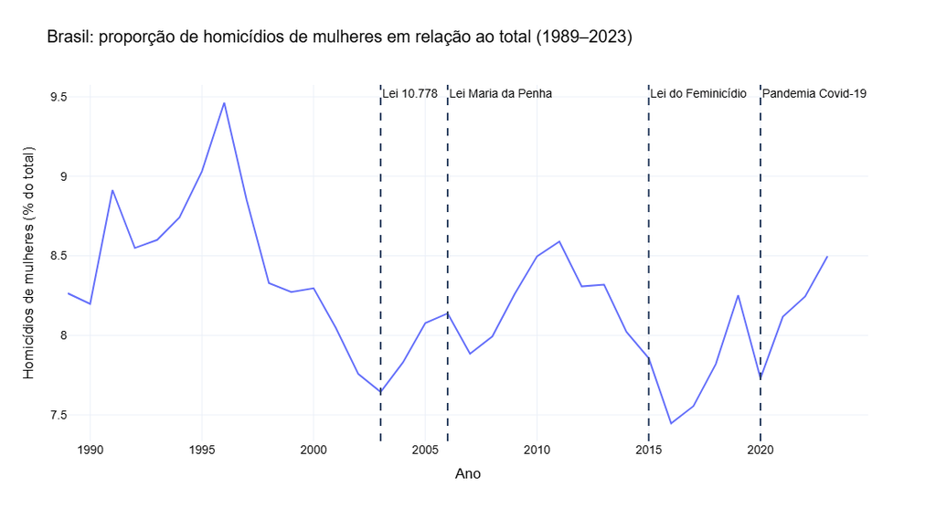

```python
fig = px.line(
    df_br_pct,
    x="periodo",
    y="pct_mulheres",
    title="Brasil: proporção de homicídios de mulheres em relação ao total (1989–2023)",
    labels={
        "periodo": "Ano",
        "pct_mulheres": "Homicídios de mulheres (% do total)"
    }
)

fig.add_vline(x=2003, line_dash="dash", annotation_text="Lei 10.778")
fig.add_vline(x=2006, line_dash="dash", annotation_text="Lei Maria da Penha")
fig.add_vline(x=2015, line_dash="dash", annotation_text="Lei do Feminicídio")
fig.add_vline(x=2020, line_dash="dash", annotation_text="Pandemia Covid-19")

fig.update_layout(
    height=600,
    width=1100,
    template="plotly_white",
    paper_bgcolor="white",
    plot_bgcolor="white",
    font=dict(
        family="Arial",
        size=14,
        color="black"
    ),
    legend=dict(
        orientation="h",
        yanchor="bottom",
        y=1.02,
        xanchor="center",
        x=0.5
    )
)
```

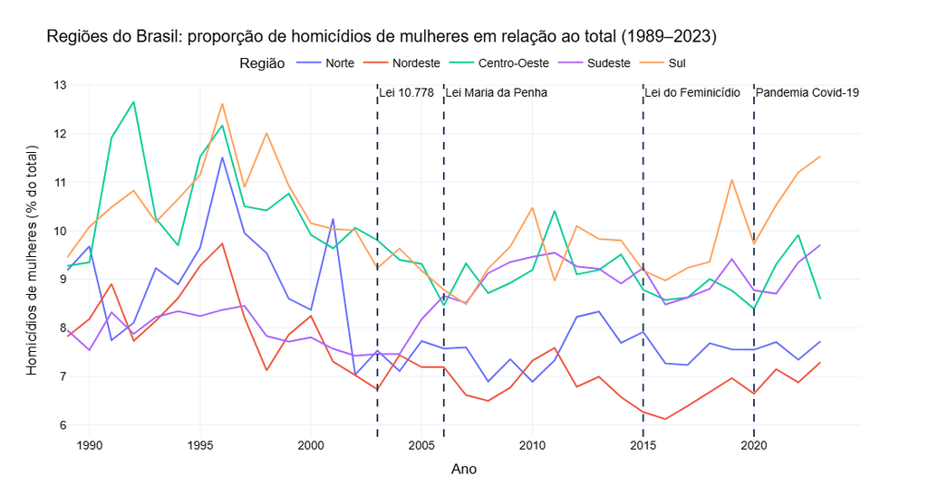

```python
df_reg_pct = (
    df_pct
    .groupby(["Regiao", "periodo"], as_index=False)
    .agg(
        mulheres=("homicidios_mulheres_total", "sum"),
        total=("homicidios_total", "sum")
    )
)

df_reg_pct["pct_mulheres"] = df_reg_pct["mulheres"] / df_reg_pct["total"] * 100

ordem_regioes = ["Norte", "Nordeste", "Centro-Oeste", "Sudeste", "Sul"]
df_reg_pct["Regiao"] = pd.Categorical(df_reg_pct["Regiao"], categories=ordem_regioes, ordered=True)
df_reg_pct = df_reg_pct.sort_values(["Regiao", "periodo"])

fig = px.line(
    df_reg_pct,
    x="periodo",
    y="pct_mulheres",
    color="Regiao",
    title="Regiões do Brasil: proporção de homicídios de mulheres em relação ao total (1989–2023)",
    labels={
        "periodo": "Ano",
        "pct_mulheres": "Homicídios de mulheres (% do total)",
        "Regiao": "Região"
    }
)

fig.add_vline(x=2003, line_dash="dash", annotation_text="Lei 10.778")
fig.add_vline(x=2006, line_dash="dash", annotation_text="Lei Maria da Penha")
fig.add_vline(x=2015, line_dash="dash", annotation_text="Lei do Feminicídio")
fig.add_vline(x=2020, line_dash="dash", annotation_text="Pandemia Covid-19")

fig.update_layout(
    height=600,
    width=1100,
    template="plotly_white",
    paper_bgcolor="white",
    plot_bgcolor="white",
    font=dict(
        family="Arial",
        size=14,
        color="black"
    ),
    legend=dict(
        orientation="h",
        yanchor="bottom",
        y=1.02,
        xanchor="center",
        x=0.5
    )
)

fig.show()
```

```python
df_reg_pct_exib = df_reg_pct.copy()
df_reg_pct_exib["pct_mulheres"] = df_reg_pct_exib["pct_mulheres"].round(2)

df_reg_pct_exib.head(200)
```

|  | Regiao | periodo | mulheres | total | pct_mulheres |
| --- | --- | --- | --- | --- | --- |
| 70 | Norte | 1989 | 163.0 | 1775.0 | 9.18 |
| 71 | Norte | 1990 | 184.0 | 1901.0 | 9.68 |
| 72 | Norte | 1991 | 153.0 | 1976.0 | 7.74 |
| 73 | Norte | 1992 | 148.0 | 1826.0 | 8.11 |
| 74 | Norte | 1993 | 165.0 | 1788.0 | 9.23 |
| 75 | Norte | 1994 | 169.0 | 1900.0 | 8.89 |
| 76 | Norte | 1995 | 178.0 | 1844.0 | 9.65 |
| 77 | Norte | 1996 | 219.0 | 1902.0 | 11.51 |
| 78 | Norte | 1997 | 195.0 | 1959.0 | 9.95 |
| 79 | Norte | 1998 | 214.0 | 2243.0 | 9.54 |
| 80 | Norte | 1999 | 183.0 | 2128.0 | 8.60 |
| 81 | Norte | 2000 | 200.0 | 2389.0 | 8.37 |
| 82 | Norte | 2001 | 271.0 | 2644.0 | 10.25 |
| 83 | Norte | 2002 | 207.0 | 2944.0 | 7.03 |
| 84 | Norte | 2003 | 237.0 | 3147.0 | 7.53 |
| 85 | Norte | 2004 | 225.0 | 3166.0 | 7.11 |
| 86 | Norte | 2005 | 284.0 | 3675.0 | 7.73 |
| 87 | Norte | 2006 | 305.0 | 4029.0 | 7.57 |
| 88 | Norte | 2007 | 301.0 | 3962.0 | 7.60 |
| 89 | Norte | 2008 | 332.0 | 4815.0 | 6.90 |
| 90 | Norte | 2009 | 379.0 | 5155.0 | 7.35 |
| 91 | Norte | 2010 | 412.0 | 5983.0 | 6.89 |
| 92 | Norte | 2011 | 411.0 | 5608.0 | 7.33 |
| 93 | Norte | 2012 | 498.0 | 6054.0 | 8.23 |
| 94 | Norte | 2013 | 505.0 | 6060.0 | 8.33 |
| 95 | Norte | 2014 | 481.0 | 6255.0 | 7.69 |
| 96 | Norte | 2015 | 549.0 | 6937.0 | 7.91 |
| 97 | Norte | 2016 | 571.0 | 7859.0 | 7.27 |
| 98 | Norte | 2017 | 613.0 | 8472.0 | 7.24 |
| 99 | Norte | 2018 | 639.0 | 8317.0 | 7.68 |

[output cut: 145 more lines]

```python
import pandas as pd
import plotly.express as px

df_corr = (
    df_uf2
    .pivot_table(
        index=["UF", "Nome_UF", "Regiao", "periodo"],
        columns="serie",
        values="valor_total",
        aggfunc="sum"
    )
    .reset_index()
)

colunas_series = [
    "homicidios_total",
    "homicidios_mulheres_total",
    "homicidios_mulheres_negras",
    "homicidios_mulheres_nao_negras",
    "homicidios_jovens_mulheres",
    "homicidios_mulheres_armas_fogo"
]

corr_pearson = df_corr[colunas_series].corr(method="pearson")
corr_spearman = df_corr[colunas_series].corr(method="spearman")

corr_pearson
```

| serie | homicidios_total | homicidios_mulheres_total | homicidios_mulheres_negras | homicidios_mulheres_nao_negras | homicidios_jovens_mulheres | homicidios_mulheres_armas_fogo |
| --- | --- | --- | --- | --- | --- | --- |
| homicidios_total | 1.000000 | 0.974243 | 0.962332 | 0.443543 | 0.966476 | 0.953544 |
| homicidios_mulheres_total | 0.974243 | 1.000000 | 0.888979 | 0.673273 | 0.975214 | 0.945209 |
| homicidios_mulheres_negras | 0.962332 | 0.888979 | 1.000000 | 0.260055 | 0.928152 | 0.950632 |
| homicidios_mulheres_nao_negras | 0.443543 | 0.673273 | 0.260055 | 1.000000 | 0.365509 | 0.396469 |
| homicidios_jovens_mulheres | 0.966476 | 0.975214 | 0.928152 | 0.365509 | 1.000000 | 0.935499 |
| homicidios_mulheres_armas_fogo | 0.953544 | 0.945209 | 0.950632 | 0.396469 | 0.935499 | 1.000000 |

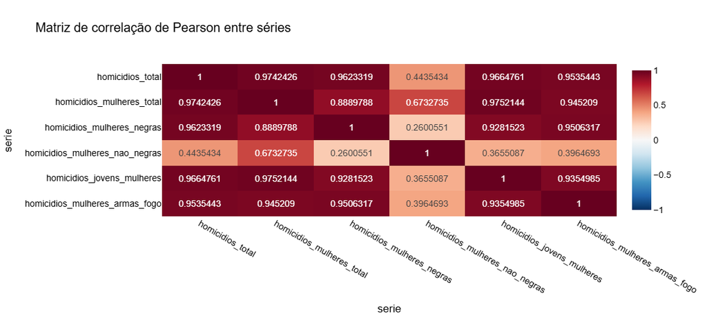

```python
fig = px.imshow(
    corr_pearson,
    text_auto=True,
    aspect="auto",
    title="Matriz de correlação de Pearson entre séries",
    color_continuous_scale="RdBu_r",
    zmin=-1,
    zmax=1
)

fig.update_layout(
    height=500,
    width=1000,
    template="plotly_white",
    paper_bgcolor="white",
    plot_bgcolor="white",
    font=dict(
        family="Arial",
        size=14,
        color="black"
    ),
    legend=dict(
        orientation="h",
        yanchor="bottom",
        y=1.02,
        xanchor="center",
        x=0.5
    )
)

fig.show()
```

```python
fig = px.imshow(
    corr_spearman,
    text_auto=True,
    aspect="auto",
    title="Matriz de correlação de Spearman entre séries",
    color_continuous_scale="RdBu_r",
    zmin=-1,
    zmax=1
)

fig.update_layout(height=700)
fig.show()
```

```python
import pandas as pd
import numpy as np
from scipy.stats import chi2_contingency

serie = "homicidios_mulheres_total"

df_chi = df_uf2[df_uf2["serie"] == serie].copy()

df_chi["periodo_grupo"] = np.where(df_chi["periodo"] < 2006, "Pre_2006", "Pos_2006")

tab_chi = (
    df_chi
    .groupby(["Regiao", "periodo_grupo"], as_index=False)
    .agg(total=("valor_total", "sum"))
    .pivot(index="Regiao", columns="periodo_grupo", values="total")
    .fillna(0)
)

chi2, p, dof, expected = chi2_contingency(tab_chi)

print("Tabela observada:")
print(tab_chi)
print("\nQui-quadrado:", chi2)
print("p-valor:", p)
print("Graus de liberdade:", dof)

expected_df = pd.DataFrame(expected, index=tab_chi.index, columns=tab_chi.columns)
print("\nTabela esperada:")
print(expected_df.round(2))
```

```
Tabela observada:
periodo_grupo  Pos_2006  Pre_2006
Regiao
Centro-Oeste       7420      4888
Nordeste          25002     11257
Norte              8398      3395
Sudeste           24935     28076
Sul               10568      6686

Qui-quadrado: 5353.079884733587
p-valor: 0.0
Graus de liberdade: 4

Tabela esperada:
periodo_grupo  Pos_2006  Pre_2006
Regiao
Centro-Oeste    7191.45   5116.55
Nordeste       21185.80  15073.20
Norte           6890.54   4902.46
Sudeste        30973.85  22037.15
Sul            10081.36   7172.64
```

```python
residuos = (tab_chi - expected_df) / np.sqrt(expected_df)
residuos.round(2)
```

| periodo_grupo Regiao | Pos_2006 | Pre_2006 |
| --- | --- | --- |
| Centro-Oeste | 2.70 | -3.20 |
| Nordeste | 26.22 | -31.08 |
| Norte | 18.16 | -21.53 |
| Sudeste | -34.31 | 40.68 |
| Sul | 4.85 | -5.75 |

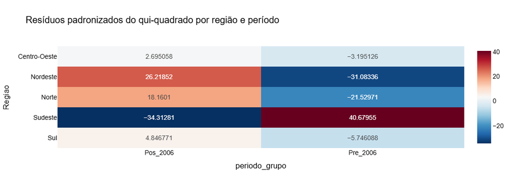

```python
fig = px.imshow(
    residuos,
    text_auto=True,
    aspect="auto",
    title="Resíduos padronizados do qui-quadrado por região e período",
    color_continuous_scale="RdBu_r"
)

fig.update_layout(
    height=400,
    width=600,
    template="plotly_white",
    paper_bgcolor="white",
    plot_bgcolor="white",
    font=dict(
        family="Arial",
        size=14,
        color="black"
    ),
    legend=dict(
        orientation="h",
        yanchor="bottom",
        y=1.02,
        xanchor="center",
        x=0.5
    )
)

fig.show()
```

```python
from scipy.stats import mannwhitneyu
import pandas as pd
import numpy as np

serie = "homicidios_mulheres_total"

df_test = df_uf2[df_uf2["serie"] == serie].copy()
df_test["grupo"] = np.where(df_test["periodo"] < 2006, "Pre_2006", "Pos_2006")

resultados = []

for uf, g in df_test.groupby("Nome_UF"):
    pre = g.loc[g["grupo"] == "Pre_2006", "valor_total"].dropna()
    pos = g.loc[g["grupo"] == "Pos_2006", "valor_total"].dropna()

    if len(pre) >= 3 and len(pos) >= 3:
        stat, p = mannwhitneyu(pre, pos, alternative="two-sided")
        resultados.append({
            "Nome_UF": uf,
            "media_pre": pre.mean(),
            "media_pos": pos.mean(),
            "mediana_pre": pre.median(),
            "mediana_pos": pos.median(),
            "dif_media": pos.mean() - pre.mean(),
            "p_valor": p
        })

df_mw = pd.DataFrame(resultados).sort_values("p_valor")
df_mw.head(27)
```

|  | Nome_UF | media_pre | media_pos | mediana_pre | mediana_pos | dif_media | p_valor |
| --- | --- | --- | --- | --- | --- | --- | --- |
| 15 | Pará | 72.176471 | 220.166667 | 72.0 | 218.5 | 147.990196 | 4.760582e-07 |
| 18 | Rio Grande do Norte | 23.764706 | 79.222222 | 22.0 | 73.5 | 55.457516 | 4.769363e-07 |
| 4 | Bahia | 129.529412 | 394.111111 | 123.0 | 418.0 | 264.581699 | 4.813472e-07 |
| 9 | Maranhão | 39.705882 | 118.444444 | 33.0 | 126.5 | 78.738562 | 6.730590e-07 |
| 3 | Amazonas | 37.235294 | 95.833333 | 35.0 | 105.5 | 58.598039 | 7.919208e-07 |
| 26 | Tocantins | 15.058824 | 36.277778 | 16.0 | 35.0 | 21.218954 | 9.358636e-07 |
| 23 | Santa Catarina | 55.352941 | 96.555556 | 51.0 | 95.0 | 41.202614 | 1.024977e-06 |
| 5 | Ceará | 81.588235 | 243.277778 | 84.0 | 234.5 | 161.689542 | 1.329981e-06 |
| 0 | Acre | 11.470588 | 22.333333 | 12.0 | 19.5 | 10.862745 | 1.922686e-06 |
| 17 | Piauí | 18.235294 | 48.833333 | 14.0 | 48.5 | 30.598039 | 2.524167e-06 |
| 1 | Alagoas | 61.000000 | 103.000000 | 62.0 | 103.5 | 42.000000 | 3.771305e-06 |
| 14 | Paraíba | 46.705882 | 96.666667 | 41.0 | 89.5 | 49.960784 | 4.108851e-06 |
| 19 | Rio Grande do Sul | 169.235294 | 235.500000 | 175.0 | 228.5 | 66.264706 | 4.842423e-06 |
| 24 | Sergipe | 26.588235 | 49.111111 | 28.0 | 43.0 | 22.522876 | 9.568976e-06 |
| 25 | São Paulo | 870.058824 | 532.666667 | 951.0 | 557.0 | -337.392157 | 1.224656e-05 |
| 8 | Goiás | 112.764706 | 192.444444 | 118.0 | 170.5 | 79.679739 | 1.911072e-05 |
| 13 | Paraná | 168.705882 | 255.055556 | 163.0 | 244.5 | 86.349673 | 2.766058e-05 |
| 12 | Minas Gerais | 223.294118 | 364.055556 | 185.0 | 387.0 | 140.761438 | 3.428104e-05 |
| 22 | Roraima | 11.000000 | 25.111111 | 10.0 | 24.5 | 14.111111 | 4.844174e-05 |
| 2 | Amapá | 10.470588 | 17.111111 | 12.0 | 17.0 | 6.640523 | 2.450402e-04 |
| 20 | Rio de Janeiro | 441.235294 | 344.166667 | 473.0 | 346.0 | -97.068627 | 2.390423e-03 |
| 10 | Mato Grosso | 67.705882 | 94.166667 | 81.0 | 93.0 | 26.460784 | 4.277645e-03 |
| 21 | Rondônia | 42.294118 | 49.722222 | 41.0 | 51.0 | 7.428105 | 1.140562e-02 |
| 7 | Espírito Santo | 116.941176 | 144.388889 | 122.0 | 146.0 | 27.447712 | 2.927980e-02 |
| 6 | Distrito Federal | 48.294118 | 58.000000 | 50.0 | 56.5 | 9.705882 | 3.888399e-02 |
| 11 | Mato Grosso do Sul | 58.764706 | 67.611111 | 63.0 | 66.5 | 8.846405 | 6.435668e-02 |
| 16 | Pernambuco | 235.058824 | 256.333333 | 231.0 | 248.5 | 21.274510 | 1.208203e-01 |

```python
df_mw["significativo_5pct"] = df_mw["p_valor"] < 0.05
df_mw["variacao_pct"] = np.where(
    df_mw["media_pre"] > 0,
    (df_mw["media_pos"] - df_mw["media_pre"]) / df_mw["media_pre"] * 100,
    np.nan
)

df_mw.sort_values(["significativo_5pct", "p_valor"], ascending=[False, True]).head(27)
```

|  | Nome_UF | media_pre | media_pos | mediana_pre | mediana_pos | dif_media | p_valor | significativo_5pct | variacao_pct |
| --- | --- | --- | --- | --- | --- | --- | --- | --- | --- |
| 15 | Pará | 72.176471 | 220.166667 | 72.0 | 218.5 | 147.990196 | 4.760582e-07 | True | 205.039391 |
| 18 | Rio Grande do Norte | 23.764706 | 79.222222 | 22.0 | 73.5 | 55.457516 | 4.769363e-07 | True | 233.360836 |
| 4 | Bahia | 129.529412 | 394.111111 | 123.0 | 418.0 | 264.581699 | 4.813472e-07 | True | 204.263801 |
| 9 | Maranhão | 39.705882 | 118.444444 | 33.0 | 126.5 | 78.738562 | 6.730590e-07 | True | 198.304527 |
| 3 | Amazonas | 37.235294 | 95.833333 | 35.0 | 105.5 | 58.598039 | 7.919208e-07 | True | 157.372301 |
| 26 | Tocantins | 15.058824 | 36.277778 | 16.0 | 35.0 | 21.218954 | 9.358636e-07 | True | 140.907118 |
| 23 | Santa Catarina | 55.352941 | 96.555556 | 51.0 | 95.0 | 41.202614 | 1.024977e-06 | True | 74.436179 |
| 5 | Ceará | 81.588235 | 243.277778 | 84.0 | 234.5 | 161.689542 | 1.329981e-06 | True | 198.177521 |
| 0 | Acre | 11.470588 | 22.333333 | 12.0 | 19.5 | 10.862745 | 1.922686e-06 | True | 94.700855 |
| 17 | Piauí | 18.235294 | 48.833333 | 14.0 | 48.5 | 30.598039 | 2.524167e-06 | True | 167.795699 |
| 1 | Alagoas | 61.000000 | 103.000000 | 62.0 | 103.5 | 42.000000 | 3.771305e-06 | True | 68.852459 |
| 14 | Paraíba | 46.705882 | 96.666667 | 41.0 | 89.5 | 49.960784 | 4.108851e-06 | True | 106.968934 |
| 19 | Rio Grande do Sul | 169.235294 | 235.500000 | 175.0 | 228.5 | 66.264706 | 4.842423e-06 | True | 39.155370 |
| 24 | Sergipe | 26.588235 | 49.111111 | 28.0 | 43.0 | 22.522876 | 9.568976e-06 | True | 84.709931 |
| 25 | São Paulo | 870.058824 | 532.666667 | 951.0 | 557.0 | -337.392157 | 1.224656e-05 | True | -38.778086 |
| 8 | Goiás | 112.764706 | 192.444444 | 118.0 | 170.5 | 79.679739 | 1.911072e-05 | True | 70.660175 |
| 13 | Paraná | 168.705882 | 255.055556 | 163.0 | 244.5 | 86.349673 | 2.766058e-05 | True | 51.183558 |
| 12 | Minas Gerais | 223.294118 | 364.055556 | 185.0 | 387.0 | 140.761438 | 3.428104e-05 | True | 63.038579 |
| 22 | Roraima | 11.000000 | 25.111111 | 10.0 | 24.5 | 14.111111 | 4.844174e-05 | True | 128.282828 |
| 2 | Amapá | 10.470588 | 17.111111 | 12.0 | 17.0 | 6.640523 | 2.450402e-04 | True | 63.420724 |
| 20 | Rio de Janeiro | 441.235294 | 344.166667 | 473.0 | 346.0 | -97.068627 | 2.390423e-03 | True | -21.999289 |
| 10 | Mato Grosso | 67.705882 | 94.166667 | 81.0 | 93.0 | 26.460784 | 4.277645e-03 | True | 39.081958 |
| 21 | Rondônia | 42.294118 | 49.722222 | 41.0 | 51.0 | 7.428105 | 1.140562e-02 | True | 17.562973 |
| 7 | Espírito Santo | 116.941176 | 144.388889 | 122.0 | 146.0 | 27.447712 | 2.927980e-02 | True | 23.471384 |
| 6 | Distrito Federal | 48.294118 | 58.000000 | 50.0 | 56.5 | 9.705882 | 3.888399e-02 | True | 20.097442 |
| 11 | Mato Grosso do Sul | 58.764706 | 67.611111 | 63.0 | 66.5 | 8.846405 | 6.435668e-02 | False | 15.053943 |
| 16 | Pernambuco | 235.058824 | 256.333333 | 231.0 | 248.5 | 21.274510 | 1.208203e-01 | False | 9.050717 |

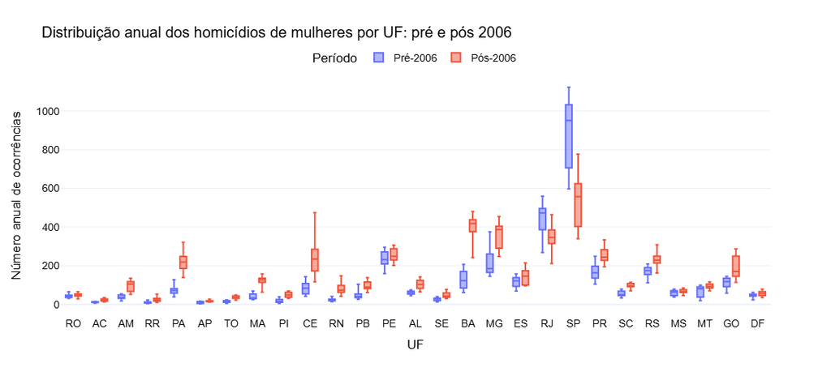

```python
import numpy as np
import plotly.express as px

serie = "homicidios_mulheres_total"

siglas_uf = {
    "Acre": "AC",
    "Alagoas": "AL",
    "Amapá": "AP",
    "Amazonas": "AM",
    "Bahia": "BA",
    "Ceará": "CE",
    "Distrito Federal": "DF",
    "Espírito Santo": "ES",
    "Goiás": "GO",
    "Maranhão": "MA",
    "Mato Grosso": "MT",
    "Mato Grosso do Sul": "MS",
    "Minas Gerais": "MG",
    "Pará": "PA",
    "Paraíba": "PB",
    "Paraná": "PR",
    "Pernambuco": "PE",
    "Piauí": "PI",
    "Rio de Janeiro": "RJ",
    "Rio Grande do Norte": "RN",
    "Rio Grande do Sul": "RS",
    "Rondônia": "RO",
    "Roraima": "RR",
    "Santa Catarina": "SC",
    "São Paulo": "SP",
    "Sergipe": "SE",
    "Tocantins": "TO"
}

df_box2 = df_uf2[df_uf2["serie"] == serie].copy()
df_box2["periodo_grupo"] = np.where(df_box2["periodo"] < 2006, "Pré-2006", "Pós-2006")
df_box2["UF"] = df_box2["Nome_UF"].map(siglas_uf)

ordem_ufs = [
    "RO","AC","AM","RR","PA","AP","TO",
    "MA","PI","CE","RN","PB","PE","AL","SE","BA",
    "MG","ES","RJ","SP",
    "PR","SC","RS",
    "MS","MT","GO","DF"
]

fig = px.box(
    df_box2,
    x="UF",
    y="valor_total",
    color="periodo_grupo",
    category_orders={"UF": ordem_ufs},
    points=False,
    title="Distribuição anual dos homicídios de mulheres por UF: pré e pós 2006",
    labels={
        "UF": "UF",
        "valor_total": "Número anual de ocorrências",
        "periodo_grupo": "Período"
    }
)

fig.update_layout(
    height=500,
    width=1100,
    template="plotly_white",
    paper_bgcolor="white",
    plot_bgcolor="white",
    font=dict(
        family="Arial",
        size=14,
        color="black"
    ),
    legend=dict(
        orientation="h",
        yanchor="bottom",
        y=1.02,
        xanchor="center",
        x=0.5
    )
)

fig.show()
```

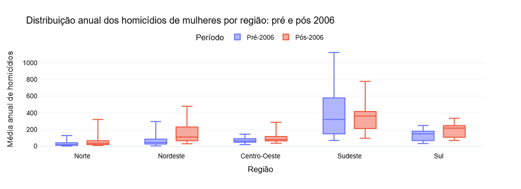

```python
import numpy as np
import plotly.express as px
import pandas as pd

serie = "homicidios_mulheres_total"

ordem_regioes = ["Norte", "Nordeste", "Centro-Oeste", "Sudeste", "Sul"]

df_box_reg = df_uf2[df_uf2["serie"] == serie].copy()
df_box_reg["periodo_grupo"] = np.where(df_box_reg["periodo"] < 2006, "Pré-2006", "Pós-2006")
df_box_reg["Regiao"] = pd.Categorical(df_box_reg["Regiao"], categories=ordem_regioes, ordered=True)

fig = px.box(
    df_box_reg,
    x="Regiao",
    y="valor_total",
    color="periodo_grupo",
    points=False,
    category_orders={"Regiao": ordem_regioes},
    title="Distribuição anual dos homicídios de mulheres por região: pré e pós 2006",
    labels={
        "Regiao": "Região",
        "valor_total": "Média anual de homicídios",
        "periodo_grupo": "Período"
    }
)

fig.update_layout(
    height=400,
    width=600,
    template="plotly_white",
    paper_bgcolor="white",
    plot_bgcolor="white",
    font=dict(
        family="Arial",
        size=14,
        color="black"
    ),
    legend=dict(
        orientation="h",
        yanchor="bottom",
        y=1.02,
        xanchor="center",
        x=0.5
    )
)

fig.show()
```

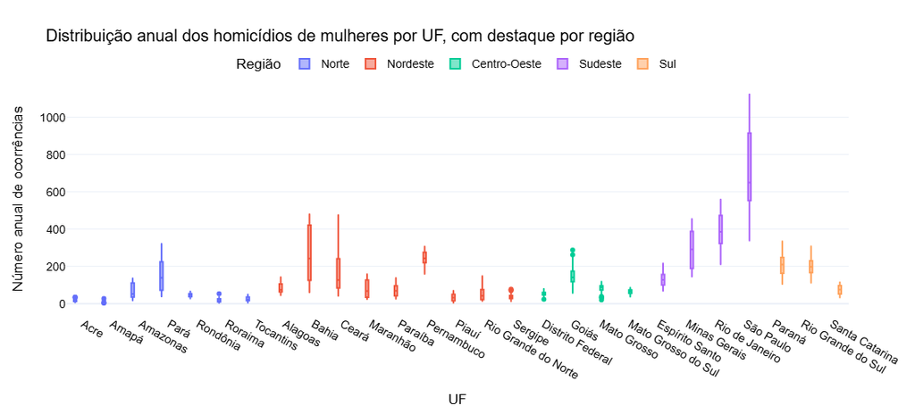

```python
fig = px.box(
    df_box,
    x="Nome_UF",
    y="valor_total",
    color="Regiao",
    points="outliers",
    title="Distribuição anual dos homicídios de mulheres por UF, com destaque por região",
    labels={
        "Nome_UF": "UF",
        "valor_total": "Número anual de ocorrências",
        "Regiao": "Região"
    }
)


fig.update_layout(
    height=500,
    width=1100,
    template="plotly_white",
    paper_bgcolor="white",
    plot_bgcolor="white",
    font=dict(
        family="Arial",
        size=14,
        color="black"
    ),
    legend=dict(
        orientation="h",
        yanchor="bottom",
        y=1.02,
        xanchor="center",
        x=0.5
    )
)

fig.show()
```

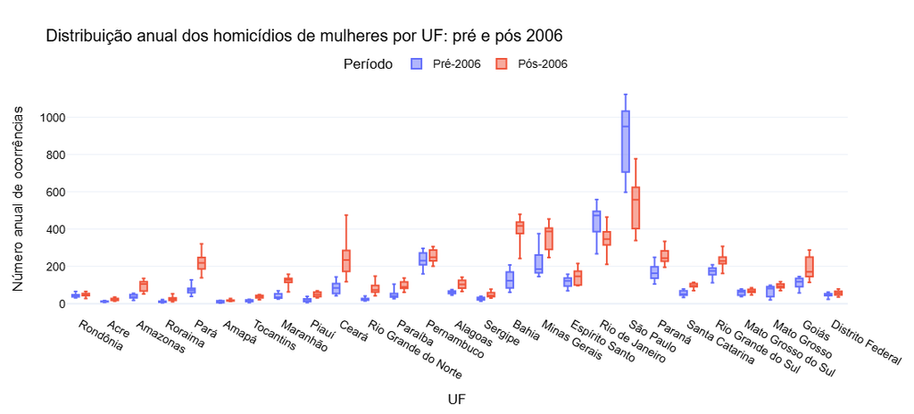

```python
import numpy as np

serie = "homicidios_mulheres_total"

df_box2 = df_uf2[df_uf2["serie"] == serie].copy()
df_box2["periodo_grupo"] = np.where(df_box2["periodo"] < 2006, "Pré-2006", "Pós-2006")

fig = px.box(
    df_box2,
    x="Nome_UF",
    y="valor_total",
    color="periodo_grupo",
    points=False,
    title="Distribuição anual dos homicídios de mulheres por UF: pré e pós 2006",
    labels={
        "Nome_UF": "UF",
        "valor_total": "Número anual de ocorrências",
        "periodo_grupo": "Período"
    }
)


fig.update_layout(
    height=500,
    width=1100,
    template="plotly_white",
    paper_bgcolor="white",
    plot_bgcolor="white",
    font=dict(
        family="Arial",
        size=14,
        color="black"
    ),
    legend=dict(
        orientation="h",
        yanchor="bottom",
        y=1.02,
        xanchor="center",
        x=0.5
    )
)

fig.show()
```

```python
df_part = (
    df_uf2
    .pivot_table(
        index=["UF", "Nome_UF", "Regiao", "periodo"],
        columns="serie",
        values="valor_total",
        aggfunc="sum"
    )
    .reset_index()
)

df_part["pct_negras_no_total_mulheres"] = np.where(
    df_part["homicidios_mulheres_total"] > 0,
    df_part["homicidios_mulheres_negras"] / df_part["homicidios_mulheres_total"] * 100,
    np.nan
)

df_part.head()
```

| serie | UF | Nome_UF | Regiao | periodo | homicidios_jovens_mulheres | homicidios_mulheres_armas_fogo | homicidios_mulheres_nao_negras | homicidios_mulheres_negras | homicidios_mulheres_total | homicidios_total | pct_negras_no_total_mulheres |
| --- | --- | --- | --- | --- | --- | --- | --- | --- | --- | --- | --- |
| 0 | 11 | Rondônia | Norte | 1989 | 27.0 | 25.0 | NaN | NaN | 47.0 | 482.0 | NaN |
| 1 | 11 | Rondônia | Norte | 1990 | 21.0 | 14.0 | NaN | NaN | 37.0 | 507.0 | NaN |
| 2 | 11 | Rondônia | Norte | 1991 | 11.0 | 15.0 | NaN | NaN | 31.0 | 452.0 | NaN |
| 3 | 11 | Rondônia | Norte | 1992 | 19.0 | 14.0 | NaN | NaN | 35.0 | 395.0 | NaN |
| 4 | 11 | Rondônia | Norte | 1993 | 22.0 | 23.0 | NaN | NaN | 53.0 | 477.0 | NaN |

```python
fig = px.box(
    df_part,
    x="Nome_UF",
    y="pct_negras_no_total_mulheres",
    color="Regiao",
    points="outliers",
    title="Distribuição da participação de mulheres negras nos homicídios de mulheres por UF",
    labels={
        "Nome_UF": "UF",
        "pct_negras_no_total_mulheres": "% de mulheres negras no total de homicídios de mulheres"
    }
)

fig.update_layout(height=700, xaxis_tickangle=-45)
fig.show()
```